# Ford-gobike Tripdata

## Preliminary Wrangling

```python
# import all packages and set plots to be embedded inline
import numpy as np
import pandas as pd
import matplotlib.pyplot as plt
import seaborn as sb
import glob
import os

%matplotlib inline
```

### Gathering & Assessing the data

```python
#Append all the data into one table
folder_name = 'fordbike'
frames = [pd.read_csv(f) for f in glob.glob(os.path.join(folder_name, '*.csv'))]
trips = pd.concat(frames, ignore_index=True)
trips
```

|  | duration_sec | start_time | end_time | start_station_id | start_station_name | start_station_latitude | start_station_longitude | end_station_id | end_station_name | end_station_latitude | end_station_longitude | bike_id | user_type | bike_share_for_all_trip |
| --- | --- | --- | --- | --- | --- | --- | --- | --- | --- | --- | --- | --- | --- | --- |
| 0 | 75284 | 2018-01-31 22:52:35.2390 | 2018-02-01 19:47:19.8240 | 120.0 | Mission Dolores Park | 37.761420 | -122.426435 | 285.0 | Webster St at O'Farrell St | 37.783521 | -122.431158 | 2765 | Subscriber | No |
| 1 | 85422 | 2018-01-31 16:13:34.3510 | 2018-02-01 15:57:17.3100 | 15.0 | San Francisco Ferry Building (Harry Bridges Pl... | 37.795392 | -122.394203 | 15.0 | San Francisco Ferry Building (Harry Bridges Pl... | 37.795392 | -122.394203 | 2815 | Customer | No |
| 2 | 71576 | 2018-01-31 14:23:55.8890 | 2018-02-01 10:16:52.1160 | 304.0 | Jackson St at 5th St | 37.348759 | -121.894798 | 296.0 | 5th St at Virginia St | 37.325998 | -121.877120 | 3039 | Customer | No |
| 3 | 61076 | 2018-01-31 14:53:23.5620 | 2018-02-01 07:51:20.5000 | 75.0 | Market St at Franklin St | 37.773793 | -122.421239 | 47.0 | 4th St at Harrison St | 37.780955 | -122.399749 | 321 | Customer | No |
| 4 | 39966 | 2018-01-31 19:52:24.6670 | 2018-02-01 06:58:31.0530 | 74.0 | Laguna St at Hayes St | 37.776435 | -122.426244 | 19.0 | Post St at Kearny St | 37.788975 | -122.403452 | 617 | Subscriber | No |
| ... | ... | ... | ... | ... | ... | ... | ... | ... | ... | ... | ... | ... | ... | ... |
| 1863716 | 473 | 2018-12-01 00:11:54.8110 | 2018-12-01 00:19:48.5470 | 345.0 | Hubbell St at 16th St | 37.766474 | -122.398295 | 81.0 | Berry St at 4th St | 37.775880 | -122.393170 | 3035 | Subscriber | No |
| 1863717 | 841 | 2018-12-01 00:02:48.7260 | 2018-12-01 00:16:49.7660 | 10.0 | Washington St at Kearny St | 37.795393 | -122.404770 | 58.0 | Market St at 10th St | 37.776619 | -122.417385 | 2034 | Subscriber | No |
| 1863718 | 260 | 2018-12-01 00:05:27.6150 | 2018-12-01 00:09:47.9560 | 245.0 | Downtown Berkeley BART | 37.870139 | -122.268422 | 255.0 | Virginia St at Shattuck Ave | 37.876573 | -122.269528 | 2243 | Subscriber | No |
| 1863719 | 292 | 2018-12-01 00:03:06.5490 | 2018-12-01 00:07:59.0800 | 93.0 | 4th St at Mission Bay Blvd S | 37.770407 | -122.391198 | 126.0 | Esprit Park | 37.761634 | -122.390648 | 545 | Subscriber | No |
| 1863720 | 150 | 2018-12-01 00:03:05.7420 | 2018-12-01 00:05:36.0260 | 107.0 | 17th St at Dolores St | 37.763015 | -122.426497 | 119.0 | 18th St at Noe St | 37.761047 | -122.432642 | 4319 | Subscriber | No |

1863721 rows × 14 columns

```python
#save the result to a .csv file
trips.to_csv('fordgobike_2018.csv', index=False)
```

```python
trips= pd.read_csv('fordgobike_2018.csv')
```

```python
trips.shape
```

```
(1863721, 14)
```

```python
trips.user_type.value_counts()
```

```
Subscriber    1583554
Customer       280167
Name: user_type, dtype: int64
```

```python
trips.info()
```

```
<class 'pandas.core.frame.DataFrame'>
RangeIndex: 1863721 entries, 0 to 1863720
Data columns (total 14 columns):
 #   Column                   Dtype
---  ------                   -----
 0   duration_sec             int64
 1   start_time               object
 2   end_time                 object
 3   start_station_id         float64
 4   start_station_name       object
 5   start_station_latitude   float64
 6   start_station_longitude  float64
 7   end_station_id           float64
 8   end_station_name         object
 9   end_station_latitude     float64
 10  end_station_longitude    float64
 11  bike_id                  int64
 12  user_type                object
 13  bike_share_for_all_trip  object
dtypes: float64(6), int64(2), object(6)
memory usage: 199.1+ MB
```

```python
trips.bike_share_for_all_trip.value_counts()
```

```
No     1701386
Yes     162335
Name: bike_share_for_all_trip, dtype: int64
```

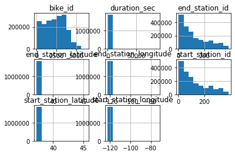

```python
trips.hist();
```

```python
trips.duplicated().sum()
```

```
0
```

### Cleaning the dataset

```python
#create a copy of the dataframe
df= trips.copy()
```

> Add new colums for trip duration minutes and hours to make it easier to evaluate duration time.

```python
#create a column for trip duration in minutes
df['duration_min'] = df['duration_sec'] / 60

#round the minute column for easier ploting
df['duration_min']= df['duration_min'].round()

#create a column for trip duration in hours
df['duration_hours'] = df['duration_min'] /60

#Test
df
```

|  | duration_sec | start_time | end_time | start_station_id | start_station_name | start_station_latitude | start_station_longitude | end_station_id | end_station_name | end_station_latitude | end_station_longitude | bike_id | user_type | bike_share_for_all_trip | duration_min | duration_hours |
| --- | --- | --- | --- | --- | --- | --- | --- | --- | --- | --- | --- | --- | --- | --- | --- | --- |
| 0 | 75284 | 2018-01-31 22:52:35.2390 | 2018-02-01 19:47:19.8240 | 120.0 | Mission Dolores Park | 37.761420 | -122.426435 | 285.0 | Webster St at O'Farrell St | 37.783521 | -122.431158 | 2765 | Subscriber | No | 1255.0 | 20.916667 |
| 1 | 85422 | 2018-01-31 16:13:34.3510 | 2018-02-01 15:57:17.3100 | 15.0 | San Francisco Ferry Building (Harry Bridges Pl... | 37.795392 | -122.394203 | 15.0 | San Francisco Ferry Building (Harry Bridges Pl... | 37.795392 | -122.394203 | 2815 | Customer | No | 1424.0 | 23.733333 |
| 2 | 71576 | 2018-01-31 14:23:55.8890 | 2018-02-01 10:16:52.1160 | 304.0 | Jackson St at 5th St | 37.348759 | -121.894798 | 296.0 | 5th St at Virginia St | 37.325998 | -121.877120 | 3039 | Customer | No | 1193.0 | 19.883333 |
| 3 | 61076 | 2018-01-31 14:53:23.5620 | 2018-02-01 07:51:20.5000 | 75.0 | Market St at Franklin St | 37.773793 | -122.421239 | 47.0 | 4th St at Harrison St | 37.780955 | -122.399749 | 321 | Customer | No | 1018.0 | 16.966667 |
| 4 | 39966 | 2018-01-31 19:52:24.6670 | 2018-02-01 06:58:31.0530 | 74.0 | Laguna St at Hayes St | 37.776435 | -122.426244 | 19.0 | Post St at Kearny St | 37.788975 | -122.403452 | 617 | Subscriber | No | 666.0 | 11.100000 |
| ... | ... | ... | ... | ... | ... | ... | ... | ... | ... | ... | ... | ... | ... | ... | ... | ... |
| 1863716 | 473 | 2018-12-01 00:11:54.8110 | 2018-12-01 00:19:48.5470 | 345.0 | Hubbell St at 16th St | 37.766474 | -122.398295 | 81.0 | Berry St at 4th St | 37.775880 | -122.393170 | 3035 | Subscriber | No | 8.0 | 0.133333 |
| 1863717 | 841 | 2018-12-01 00:02:48.7260 | 2018-12-01 00:16:49.7660 | 10.0 | Washington St at Kearny St | 37.795393 | -122.404770 | 58.0 | Market St at 10th St | 37.776619 | -122.417385 | 2034 | Subscriber | No | 14.0 | 0.233333 |
| 1863718 | 260 | 2018-12-01 00:05:27.6150 | 2018-12-01 00:09:47.9560 | 245.0 | Downtown Berkeley BART | 37.870139 | -122.268422 | 255.0 | Virginia St at Shattuck Ave | 37.876573 | -122.269528 | 2243 | Subscriber | No | 4.0 | 0.066667 |
| 1863719 | 292 | 2018-12-01 00:03:06.5490 | 2018-12-01 00:07:59.0800 | 93.0 | 4th St at Mission Bay Blvd S | 37.770407 | -122.391198 | 126.0 | Esprit Park | 37.761634 | -122.390648 | 545 | Subscriber | No | 5.0 | 0.083333 |
| 1863720 | 150 | 2018-12-01 00:03:05.7420 | 2018-12-01 00:05:36.0260 | 107.0 | 17th St at Dolores St | 37.763015 | -122.426497 | 119.0 | 18th St at Noe St | 37.761047 | -122.432642 | 4319 | Subscriber | No | 2.0 | 0.033333 |

1863721 rows × 16 columns

```python
# change the dtype to datetime
df['start_time'] = pd.to_datetime(df['start_time'])
df['end_time'] = pd.to_datetime(df['end_time'])

#create four new colums start_date in yyyy-mm-dd format, trip start hour of the day, day of week and month
df['start_date'] = df.start_time.dt.strftime('%m-%d-%Y')
df['start_timeofday'] = df.start_time.dt.strftime('%H')
df['start_day'] = df.start_time.dt.strftime('%A')
df['start_month'] = df.start_time.dt.strftime('%B')

#Test
df
```

|  | duration_sec | start_time | end_time | start_station_id | start_station_name | start_station_latitude | start_station_longitude | end_station_id | end_station_name | end_station_latitude | end_station_longitude | bike_id | user_type | bike_share_for_all_trip | duration_min | duration_hours | start_date | start_timeofday | start_day | start_month |
| --- | --- | --- | --- | --- | --- | --- | --- | --- | --- | --- | --- | --- | --- | --- | --- | --- | --- | --- | --- | --- |
| 0 | 75284 | 2018-01-31 22:52:35.239 | 2018-02-01 19:47:19.824 | 120.0 | Mission Dolores Park | 37.761420 | -122.426435 | 285.0 | Webster St at O'Farrell St | 37.783521 | -122.431158 | 2765 | Subscriber | No | 1255.0 | 20.916667 | 01-31-2018 | 22 | Wednesday | January |
| 1 | 85422 | 2018-01-31 16:13:34.351 | 2018-02-01 15:57:17.310 | 15.0 | San Francisco Ferry Building (Harry Bridges Pl... | 37.795392 | -122.394203 | 15.0 | San Francisco Ferry Building (Harry Bridges Pl... | 37.795392 | -122.394203 | 2815 | Customer | No | 1424.0 | 23.733333 | 01-31-2018 | 16 | Wednesday | January |
| 2 | 71576 | 2018-01-31 14:23:55.889 | 2018-02-01 10:16:52.116 | 304.0 | Jackson St at 5th St | 37.348759 | -121.894798 | 296.0 | 5th St at Virginia St | 37.325998 | -121.877120 | 3039 | Customer | No | 1193.0 | 19.883333 | 01-31-2018 | 14 | Wednesday | January |
| 3 | 61076 | 2018-01-31 14:53:23.562 | 2018-02-01 07:51:20.500 | 75.0 | Market St at Franklin St | 37.773793 | -122.421239 | 47.0 | 4th St at Harrison St | 37.780955 | -122.399749 | 321 | Customer | No | 1018.0 | 16.966667 | 01-31-2018 | 14 | Wednesday | January |
| 4 | 39966 | 2018-01-31 19:52:24.667 | 2018-02-01 06:58:31.053 | 74.0 | Laguna St at Hayes St | 37.776435 | -122.426244 | 19.0 | Post St at Kearny St | 37.788975 | -122.403452 | 617 | Subscriber | No | 666.0 | 11.100000 | 01-31-2018 | 19 | Wednesday | January |
| ... | ... | ... | ... | ... | ... | ... | ... | ... | ... | ... | ... | ... | ... | ... | ... | ... | ... | ... | ... | ... |
| 1863716 | 473 | 2018-12-01 00:11:54.811 | 2018-12-01 00:19:48.547 | 345.0 | Hubbell St at 16th St | 37.766474 | -122.398295 | 81.0 | Berry St at 4th St | 37.775880 | -122.393170 | 3035 | Subscriber | No | 8.0 | 0.133333 | 12-01-2018 | 00 | Saturday | December |
| 1863717 | 841 | 2018-12-01 00:02:48.726 | 2018-12-01 00:16:49.766 | 10.0 | Washington St at Kearny St | 37.795393 | -122.404770 | 58.0 | Market St at 10th St | 37.776619 | -122.417385 | 2034 | Subscriber | No | 14.0 | 0.233333 | 12-01-2018 | 00 | Saturday | December |
| 1863718 | 260 | 2018-12-01 00:05:27.615 | 2018-12-01 00:09:47.956 | 245.0 | Downtown Berkeley BART | 37.870139 | -122.268422 | 255.0 | Virginia St at Shattuck Ave | 37.876573 | -122.269528 | 2243 | Subscriber | No | 4.0 | 0.066667 | 12-01-2018 | 00 | Saturday | December |
| 1863719 | 292 | 2018-12-01 00:03:06.549 | 2018-12-01 00:07:59.080 | 93.0 | 4th St at Mission Bay Blvd S | 37.770407 | -122.391198 | 126.0 | Esprit Park | 37.761634 | -122.390648 | 545 | Subscriber | No | 5.0 | 0.083333 | 12-01-2018 | 00 | Saturday | December |
| 1863720 | 150 | 2018-12-01 00:03:05.742 | 2018-12-01 00:05:36.026 | 107.0 | 17th St at Dolores St | 37.763015 | -122.426497 | 119.0 | 18th St at Noe St | 37.761047 | -122.432642 | 4319 | Subscriber | No | 2.0 | 0.033333 | 12-01-2018 | 00 | Saturday | December |

1863721 rows × 20 columns

> Changed the dtype of the user_type as category.

```python
#change the user_type dtype to category
df['user_type'] = df['user_type'].astype('category')
```

```python
#Test
df.dtypes
```

```
duration_sec                        int64
start_time                 datetime64[ns]
end_time                   datetime64[ns]
start_station_id                  float64
start_station_name                 object
start_station_latitude            float64
start_station_longitude           float64
end_station_id                    float64
end_station_name                   object
end_station_latitude              float64
end_station_longitude             float64
bike_id                             int64
user_type                        category
bike_share_for_all_trip            object
duration_min                      float64
duration_hours                    float64
start_date                         object
start_timeofday                    object
start_day                          object
start_month                        object
dtype: object
```

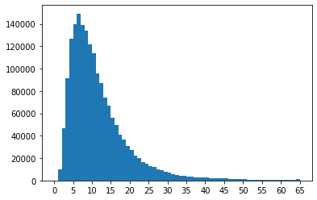

```python
#check the distribution od trip duration, examine for outliers
bins = np.arange(0, 66, 1)
ticks = np.arange(0, 66, 5)
plt.hist(df['duration_min'].dropna(), bins=bins);
plt.xticks(ticks, ticks);
```

```python
#filter outliers duration min
df=df.loc[df.duration_min < 50]
```

### What is/are the main feature(s) of interest in your dataset?

> What I am most interested in discovering is what variables are best for determining how far a user travels.During what times are bikes most rented? In which months sre there more rentals? Does the fact that a user is a customer or subscriber affect the outcome?

### What features in the dataset do you think will help support your investigation into your feature(s) of interest?

> I think that the starting and ending station latitude, station_longitude will help to determine how far they travel.The user type will be helpfull to see who the majority of their customer base is.

## Univariate Exploration

> Series of plots to explore trip distribution over months, days of the week, start time of day.

```python
new_palette = sb.color_palette('colorblind')[0]
sb.set_style('darkgrid')

# change the 'start_month' dtype to category for easier plotting.
month = ['January', 'February', 'March', 'April', 'May', 'June', 'July', 'August', 'September', 'October', 'November', 'December']
monthcat = pd.api.types.CategoricalDtype(ordered=True, categories=month)
df['start_month'] = df.loc['start_month'].astype(monthcat)
counts = df.start_month.value_counts()
```

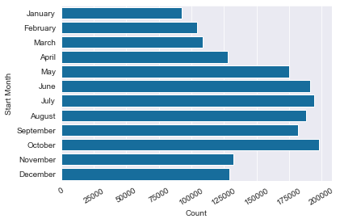

```python
#trip distribution over months
sb.countplot(data=df, y='start_month', color=new_palette);
plt.xticks(rotation=30);
plt.xlabel('Count');
plt.ylabel('Start Month');
```

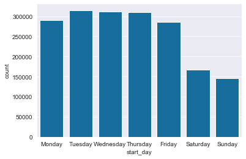

```python
# change the 'start_dayofweek' dtype to category for easier plotting.
weekday = ['Monday', 'Tuesday', 'Wednesday', 'Thursday', 'Friday', 'Saturday', 'Sunday']
weekdaycat = pd.api.types.CategoricalDtype(ordered=True, categories=weekday)
df['start_day'] = df['start_day'].astype(weekdaycat)

#trip distribution by day of the week
sb.countplot(x='start_day', data= df, color=new_palette);
```

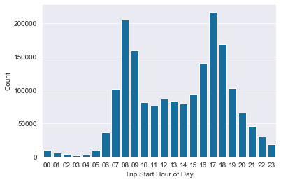

```python
#trip distribution by start hour of day
sb.countplot(data=df, x='start_timeofday', color=new_palette);
plt.xlabel('Trip Start Hour of Day');
plt.ylabel('Count');
```

> The distributions for trip start times peak at two points during the day 8am-9am & 5pm-6pm, Monday-Friday during typical rush hours. The month with the highest amount of trips is October compared to the other months, though the months with the most activity seem to be from May through October, this is most likely due to the weather during those months.

> The next plot will be the trip duration.

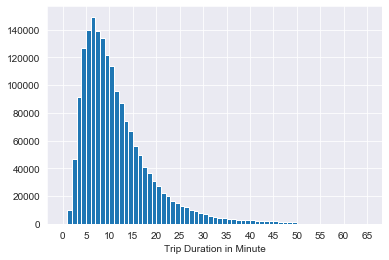

```python
#trip duration distribution by min
bins = np.arange(0, 66, 1)
ticks = np.arange(0, 66, 5)
plt.hist(data=df, x='duration_min', bins=bins);
plt.xticks(ticks, ticks);
plt.xlabel('Trip Duration in Minute');
```

```python
df['duration_min'].describe()
```

[output not shown]

> Acording to the plot most of the trips were within 50min with the majority of trips lasting between 5-10 minutes.

> The next plots will focus on the user types and bike sharing

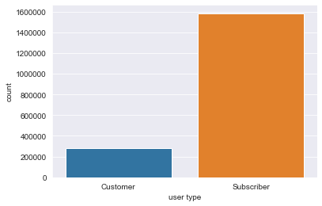

```python
sb.countplot(data=df, x='user_type')
plt.xlabel('user type')
plt.ylabel('count');
```

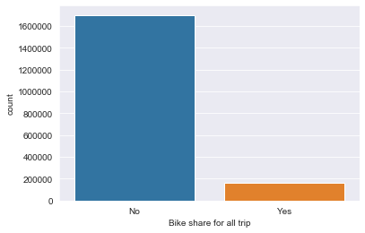

```python
sb.countplot(data=df, x='bike_share_for_all_trip')
plt.xlabel('Bike share for all trip')
plt.ylabel('count');
```

> The majority of the users in the dataset are subscribers by a vast majority. and the majority did not use bike share.

### Discuss the distribution(s) of your variable(s) of interest. Were there any unusual points? Did you need to perform any transformations?

Acording to the plots the number of trips peaked around 7-9am and 16-18pm daily, there were more trips on weekdays compared to weekends specificaly tuesday, wednesday, and thursday, with tuesday being the highest. The most popular months were May through October, likely due to the warmer weather.

User-wise, there were more members were subscribers compared to casual riders. The majority of the members did not use bike share for all of their trips.

Most rides were quick and short, lasted between 5 to 10 minutes, though there were some very long outliers like 24hrs or longer.

No transformation was needed luckily due to the straightforwardness of the data.

### Of the features you investigated, were there any unusual distributions? Did you perform any operations on the data to tidy, adjust, or change the form of the data? If so, why did you do this?

> The distribution of the trip duration was a little surprising at first plotting out the original data. Used .describe() and xticks() to zoom in to a smaller range where most trip records fell, which made the distribution much clearer. In order to help focusing on the main cases of typical use of the system, I filtered out the outlier long trip records for the study with .query().

## Bivariate Exploration

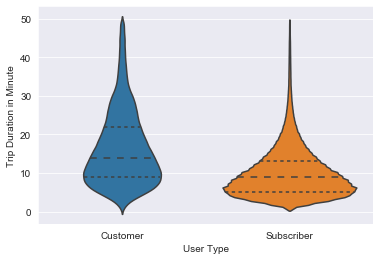

```python
sb.violinplot(data=df2, x='user_type', y='duration_min', inner='quartile');
plt.xlabel('User Type');
plt.ylabel('Trip Duration in Minute');
```

> The distribution of the trip duration is much narrower for subscribers compared to customers on the shorter and quicker trips overall. It would seem subscribers have a more consistant riding pattern compared to customers who vary more and generally rented the bikes for longer.

> The next plot shows the average trip duration for every day of the week.

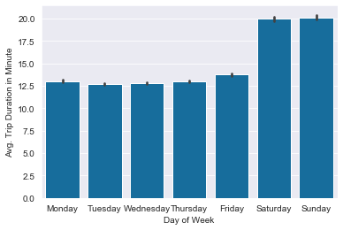

```python
sb.barplot(data=df, x='start_day', y='duration_min',color=new_palette);
plt.xlabel('Day of Week');
plt.ylabel('Avg. Trip Duration in Minute');
```

> The riding trip duration is shorter during week days compared weekends. It seem to show a consistant use during work days, and longer rides during the wekends.

> The next plot shows trip duration by month

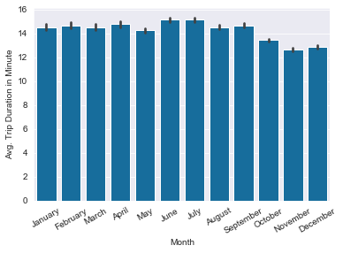

```python
sb.barplot(data=df, x='start_month', y='duration_min', color=new_palette);
plt.xticks(rotation=30);
plt.xlabel('Month');
plt.ylabel('Avg. Trip Duration in Minute');
```

> The following plot shows the member usage by day of the week and by the time of day.

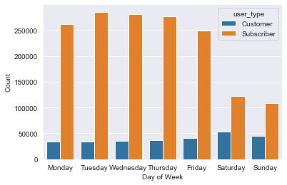

```python
sb.countplot(data=df, x='start_day', hue='user_type');
plt.xlabel('Day of Week');
plt.ylabel('Count');
```

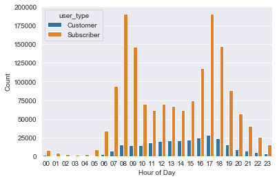

```python
sb.countplot(data=df, x='start_timeofday', hue='user_type');
plt.xlabel('Hour of Day');
plt.ylabel('Count');
```

> Subscriber usage is significantly higer than regular customer usage every day of the week. the highest volume of usage is on workdays which would sugest subscribers use the bikes mostly to commute.on the weekends the subscriber usage goes down significantly and the regular customer increased slightly. The time of day usage for subscribers also peaks during rush hour between 7am-9am and 4pm-6pm that seems to imply that they use the service to comute back and forth from work.

> The following plot show the the user type activity for every month.

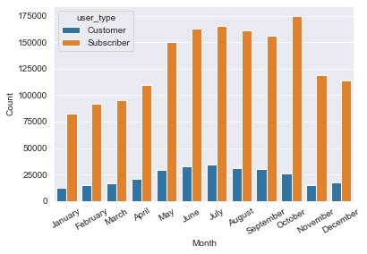

```python
sb.countplot(data=df, x='start_month', hue='user_type');
plt.xticks(rotation=30);
plt.xlabel('Month');
plt.ylabel('Count');
```

> It seems that both the subscribers and the customers ride most during the warmer months between April and October peaking in July and October. simmilarly the usage reduced during the colder months between November through March.

### Talk about some of the relationships you observed in this part of the investigation. How did the feature(s) of interest vary with other features in the dataset?

> As shown through the investigation its obvious there are more subscribers than customers. The usage of the bikes vary between the subscribers and customers, the subscribers seem to use the bikes more for comutting back and forth from work mostly during rush hour in the morning and afternoon, while the customers use the bikes for recreational purpose in the afternoons and evenings.

### Did you observe any interesting relationships between the other features (not the main feature(s) of interest)?

> It is interesting to see that subscribers use the service more than customers on average but take much shorter/quicker rides. And October had the most bike riding usage for subscribers throughout the year considering the temperature at that time is not ideal .

## Multivariate Exploration

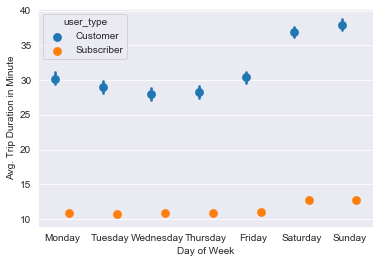

```python
sb.pointplot(data=df, x='start_day', y='duration_min', hue='user_type', dodge=0.3, linestyles="");
plt.xlabel('Day of Week');
plt.ylabel('Avg. Trip Duration in Minute');
```

> We can clearly see in the above plot that the customers have a much longer trip duration than subscribers, the subscriber usage is more consistant through the week(Mon-Fri) with bothe subscribers and customers having an increase in ride duration on the weekends.

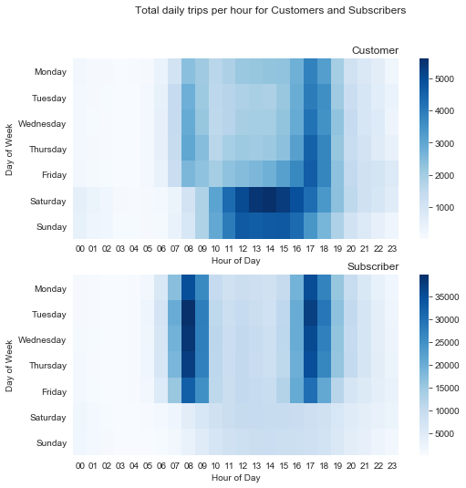

```python
plt.figure(figsize=[8, 8]);
plt.suptitle('Total daily trips per hour for Customers and Subscribers')

plt.subplot(2, 1, 1)
customers = df.query('user_type == "Customer"')
ct_counts = customers.groupby(['start_day', 'start_timeofday']).size()
ct_counts = ct_counts.reset_index(name='count')
ct_counts = ct_counts.pivot(index='start_day', columns='start_timeofday', values='count')
sb.heatmap(ct_counts, cmap='Blues');
plt.title('Customer', loc='right');
plt.xlabel('Hour of Day');
plt.ylabel('Day of Week');


plt.subplot(2, 1, 2)
subscribers = df.query('user_type == "Subscriber"')
st_counts = subscribers.groupby(['start_day', 'start_timeofday']).size()
st_counts = st_counts.reset_index(name='count')
st_counts = st_counts.pivot(index='start_day', columns='start_timeofday', values='count')
sb.heatmap(st_counts, cmap='Blues');
plt.title('Subscriber', loc='right');
plt.xlabel('Hour of Day');
plt.ylabel('Day of Week');
```

The heatmaps above further corroborate what was seen in the previous section. The usage patterns between subscribers/customer are clearly different, Subscribers use the service heavily Mon-Fri going and coming from work.Simmilarly Customers seem to also use the service at simmilar times as Subscribers but in much less volume,with the majority instead mostly riding during the weekend or later in the afternoon.

### Talk about some of the relationships you observed in this part of the investigation. Were there features that strengthened each other in terms of looking at your feature(s) of interest?

> The multivariate exploration strengthened some of the patterns discovered in the previous bivariate exploration as well as univariate exploration, the relationship between the multiple variables The efficient/short period of usage for subscribers corresponds to their high concentration on rush hours Monday through Friday, indicating the use is primarily for work commute. The more relaxing and flexible pattern of customer use shows that they're taking advantage of the bike sharing system quite differently from the subscribers, heavily over weekends and in the afternoon, most likely for recreational activities.

### Were there any interesting or surprising interactions between features?

> The interactions between features are all supplementing each other, and when looked at combined paint a sensible picture, there's no big surprise observed. The usage habit difference between customers and subscribers is very different, I was expecting to see far more customer usage than subscribers with subscribers having longer trip durations but this was not the case.